# Meeting report

Alain Danet

July 05 2022

# 1 Abstract/summary (so far)

- Downstream gradient is related more dissimilarity through time
- Human pressure recent increase is related more dissimilarity through time and less species richness increase
- Cluster analysis reveals 6 contrasted scenarios of biodiversity trends, indicating a low dimensionality of biodiversity trends
- Cluster analysis seems reveal that the spatial heterogeneity of biodiversity changes takes place at lower scale that previously shown (Blowes et al. 2019; Klink et al. 2020) (might be a caracteristic of a stream)

# 2 Introduction

## 2.1 Documenting community changes

- Global changes have affect a tremendous effect communities
- Understanding assembly and disassembly rules
- Give a more complex and complete picture of what is going on ?
- Many papers report temporal trends of local species richness and turnover
  - Abundance (Klink et al. 2020)
  - Species richness and or turnover: Blowes et al. (2019)
  - They describe basically no trends in species richness but high turnover
  - Species turnover vary a lot according to geography and taxa (Blowes et al. 2019)
  - Species turnover (as opposite of nestedness (**baselga_temporal_2013?**)) has been reported to be the major change, i.e. change in species identity, which is coherent with the absence of species richness trends

## 2.2 Multiple facets of biodiversity

- To complete

## 2.3 Long-term and short term pressure

- Occidental environment has been the most modified
- Human footprint decreased between 1993 and 2009 in Occidental countries: https://www.nature.com/articles/ncomms12558

## 2.4 Research gap

- Biodiversity trends are often analysed one facet at a time
- Ecological drivers are often not included in Biodiversity trends assessment at global scale
- Spatial grain is often at the continental scale, hiding more local heterogeneity

## 2.5 Fish freshwater in streams

- Streams are a good model to study turnover:
  - They are spatially delimited at the basin level
  - Stream fishes are strongly constrained by hydrological constrains, which are highly variable at a small spatial scale, making possible to ecological drivers at multiple places, here the basin scale.

# 3 Methods

## 3.1 Data selection

```r
filtered_dataset  <- map(filtered_dataset,
  ~.x %>%
    filter(siteid %in% unique(modelling_data$siteid))
)

uabun <- tabyl_df(filtered_dataset$site_quali, "unitabundance") %$%
  setNames(.$percent, .$unitabundance)
protocol <- tabyl_df(filtered_dataset$site_quali, "protocol")
electro <- str_detect(filtered_dataset$site_quali$protocol, "Electro") %>%
  sum / nrow(filtered_dataset$site_quali) * 100

year_samp <- modelling_data %>%
  summarise(enframe(summary_distribution(year))) %>%
  mutate(value = round(value)) %>%
  deframe()

year_samp_hft <- modelling_data %>%
  summarise(
    be93 = sum(year <= 1993) / n(),
    a93 = sum(year > 1993) / n(),
    bw9309 = sum(year > 1993 & year <= 2009) / n(),
    a09 = sum(year > 2009) / n()
    ) %>%
  mutate(across(everything(), scales::percent)) %>%
  pivot_longer(everything(), names_to = "name", values_to = "value") %>%
  deframe()
```

- Unique protocol and unique unit of abundance by site
- One sampling by year and site
- In each site, samplings should be in the median (more or less one month and half, i.e. 1.5 month)
- 5 samplings minimum by site, span 10 years
- 4476 sites
- 97.8% of the sites were monitored with electrofishing
- The year of samplings goes from 1957 to 2019 with first, second and third quartile being respectively 2000, 2006, 2012.

```r
loc <- filtered_dataset$location %>%
  left_join(filtered_dataset$site_quali, by = "siteid") %>%
  st_as_sf(coords = c("longitude", "latitude"),
  crs = 4326)
```

```r
fig_sites <- paste0(
  "Distribution of the sites.")
```

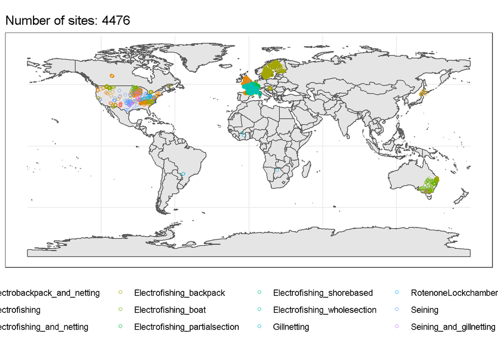

Figure 3.1: Distribution of the sites.

```r
ggplot(data = world) +
    geom_sf() +
    geom_sf(data = loc, aes(color = protocol), shape = 1) +
#    coord_sf(xlim = bb[c("xmin", "xmax")],
#      ylim = bb[c("ymin", "ymax")],
#      datum = 4326, expand = TRUE) +
    theme(legend.position = "bottom") +
    labs(title = paste0("Number of sites: ", nrow(loc)))
```

## 3.2 Biodiversity

### 3.2.1 Total abundance

Total abundance was reported in four different units: Count, Count by 100m^2, Leslie index & CPUE. The two first units account for 80% of the data.

### 3.2.3 Betadiversity

Betadiversity metrics compares the composition of two communities. In our case, we compare the composition of each time step relatively to the baseline, i.e. the first year of sampling.

- Species exchange index: (Hillebrand et al. 2018)
  - Presence-absence: $J = SER_r = \dfrac{S_{imm} + S_{lost}}{S_{tot}}$
  - Relative abundance: $SER_a = \dfrac{\sum_i (p_i - p^{\prime}_i)^2}{\sum_i p_i^2 + \sum_i p^{\prime2}_i - \sum_i p_i p^{\prime}_i}$
  - $S_{imm}$, $S_{lost}$, $S_{tot}$: number of immigrant, lost and total species respectively
  - $i$: species $i$, $p$: relative abundance, $\prime$: second community
  - $J$: Jaccard index

Turnover metrics based on presence/absence can be decomposed in appearance/disappearance and nestedness / turnover.

- appearance: $\dfrac{S_{imm}}{S_{tot}}$, disappearance: $\dfrac{S_{lost}}{S_{tot}}$
- Turnover: $J_t = \dfrac{2 * min(S_{lost}, S_{imm})}{S_{common} + (2 * min(S_{lost}, S_{imm})}$
- Nestedness: $SER_r - J_t$

# 4 Environment

```r
var_pca <- dimnames(pca_riv_str$rotated$loadings)[[1]]
clean_var_pca <- get_river_atlas_significant_var()[
  get_river_atlas_significant_var() %in% var_pca]
high_load_rc1 <- pca_riv_str$rotated$loadings[
pca_riv_str$rotated$loadings[, "RC1"] > .90,
  "RC1"]
clean_high_load_rc1_var <- get_river_atlas_significant_var()[
  get_river_atlas_significant_var() %in% names(high_load_rc1)]
```

- The environment was characterized by the stream structure and human footprint difference between 2009 and 1993
- The stream structure was characterized by a rotated PCA axis (fig 4.1). The PCA included dist_up_km, ord_stra, ele_mt_cav, slp_dg_cav, dis_m3_pyr, which are respectively Distance from source, Strahler order, Average elevation (m), Average slope (degree), Annual average of discharge (m3/s). Then, the first axis included in the analysis is associated with the following variables: Distance from source, Strahler order, Annual average of discharge (m3/s).

```r
fig_cap_pca <- "Rotated PCA on stream structure. The first axis is related to
the distance from the source, stralher order and discharge (m3/s). The second
axis is related to the altitude and slope degree of the site. Only the first
axis was included in the analysis"
```

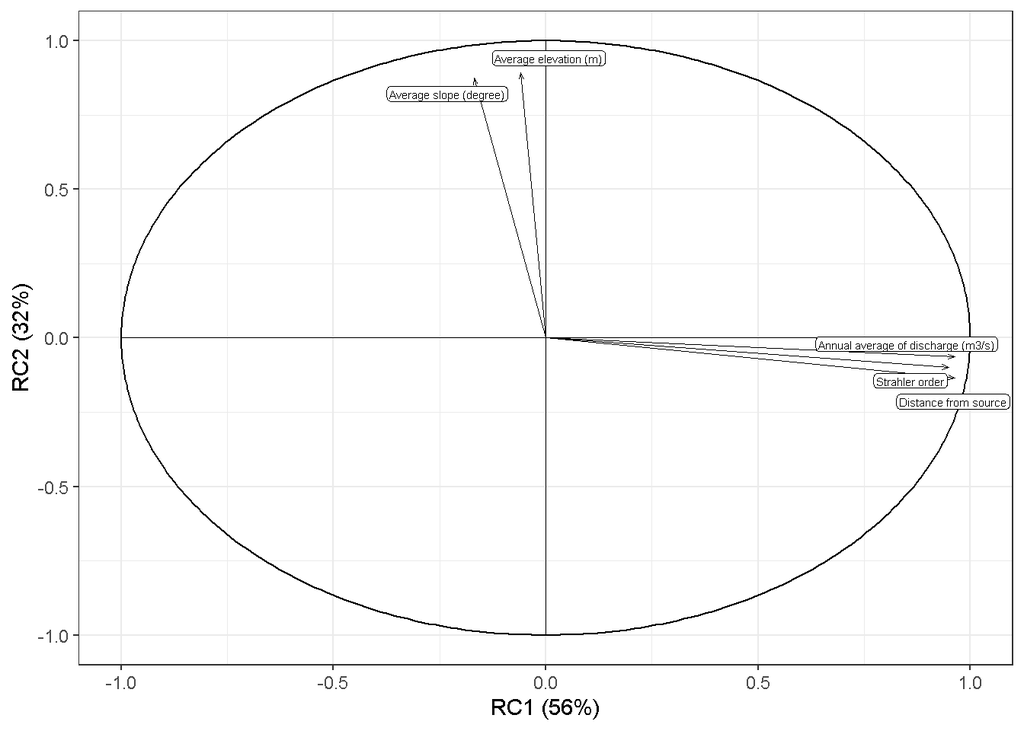

Figure 4.1: Rotated PCA on stream structure. The first axis is related to the distance from the source, stralher order and discharge (m3/s). The second axis is related to the altitude and slope degree of the site. Only the first axis was included in the analysis

```r
my_pca_plot(pca_riv_str$rotated)
```

```r
h_hft_cap <- "Distribution of log base 2 ratio between human footprint in 1993 and
2009. -1 and +1 means an Human footprint respectively divided and multiplied by
      two"
```

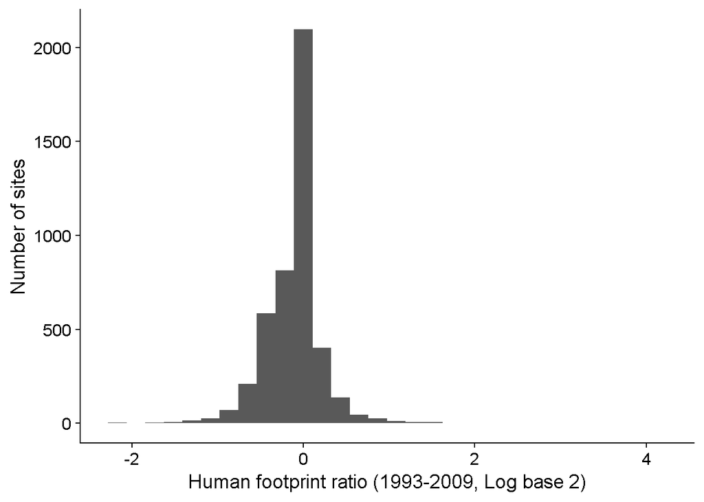

Figure 4.2: Distribution of log base 2 ratio between human footprint in 1993 and 2009. -1 and +1 means an Human footprint respectively divided and multiplied by two

```r
modelling_data %>%
  group_by(siteid) %>%
  summarise(hft_ix_c9309_log2_ratio = unique(hft_ix_c9309_log2_ratio)) %>%
  ggplot(aes(x = hft_ix_c9309_log2_ratio)) +
  geom_histogram() +
  labs(
    x = "Human footprint ratio (1993-2009, Log base 2)",
    y = "Number of sites"
  ) +
theme_cowplot()
```

```r
s_hft_diff <- round(summary_distribution(modelling_data$hft_ix_c9309_log2_ratio, na.rm = T), 2)
```

- The human footprint difference between 1993 and 2009 is biaised toward an decrease of human footprint (average difference (sd): -0.1 (0.33)), meaning that in average the human footprint index decreased in 16 years.

# 5 Statistical analysis

## 5.1 Species composition change

In each site and at each sampling point, we computed the dissimilarity (Jaccard, Appearance, Disappearance, Turnover & Nestedness) between each time step and the reference time, i.e. the first year of sampling. Regarding the reference time step, there are two different strategies. First is to include it, i.e. setting a dissimilarity of 0 at each beginning of a time series (Blowes et al. 2019). Another strategy is to exclude the first year from the analysis (Dornelas et al. 2014). The first option logically constrains the analysis toward increasing dissimilarity as the second can capture recovery from perturbation soon after the first samplings. I guess that the first option makes more sense more it removes to sensibility to community changes happening just after the references year.

## 5.2 Model

### 5.2.1 Turnover

Jaccard dissimilarity, nestedness, turnover, appearance, disappearance and hillebrand were modelled in two ways, Beta and gaussian regression. Beta regressions are more appropriate for distribution bounded by [0,1] and are linearized by a logit link. Logit links have the cons that coefficients are less easy to interpret. So we run both gaussian and beta regressions and investigate the sensitivity of our results to modelling choice. Values of turnover were slightly transformed such as values of one and zero fitted beta regression requirements ($x' = \dfrac{x \times (N - 1) + 0.5}{N}$).

The model is defined like this:

$$\begin{align}
\\ B_i &= \beta_0Y_i + \beta_1Y_iR_i + \beta_2Y_iH_i + \beta_3Y_i{HD}_i +
\\& \beta_4Y_iR_iH_i + \beta_5Y_iR_i{HD}_i +
\\& \beta_6Y_iH_i{HD}_i + \epsilon
\end{align}$$

- where:
  - $Y$: log year number + 1
  - $R$: First component of the PCA on the river structure related to the distance from spring, annual discharge, stralher order
  - $H$: Human footprint of 1993
  - ${HD}$: Log 2 of Human footprint ratio (1993-2009)

$$\begin{align}
\\ \beta_{0}&=\beta_0 + u_{0i|j} + u_{0i}
\end{align}$$

- where:
  - $\beta$: slope
  - $u$: random effect
  - $i$: site
  - $j$: basin
- The model formula in:

```r
"biodiv_facet ~
0 + year/river_structure + year/human_footprint_diff +
(0 +  year | basin/site)"
```

```
#> [1] "biodiv_facet ~ \n0 + year/river_structure + year/human_footprint_diff +\n(0 +  year | basin/site)"
```

- `year`: logged number of year (+1) since the beginning of the monitoring (site scale)
- `river_structure`: PCA from upstream to downstream (centered and scaled)
- `human_footprint_diff`: difference between 1993 and 2009 (centered and scaled)
- `basin`: Hydrographic basin
- `site`: site

### 5.2.2 Species richness

At the difference with dissimilarity index, we modelled species richness with the intercept and the main effect of ecological drivers. We modelled logged species richness with Chao index.

$$\begin{align}
\\ B_i &= \alpha + \beta_0Y_i + \beta_1R_i + \beta_2Y_iR_i + \beta_3H_i + \beta_4Y_iH_i +
\\& \beta_5Y_iR_iH_i + \beta_6Y_iR_i{HD}_i +
\\& \beta_7Y_iH_i{HD}_i + \epsilon
\end{align}$$

$$\begin{align}
\\ \alpha&=\alpha_0 + u_{0i|j} + u_{0j}
\\ \beta_{0}&=\beta_0 + u_{0i|j} + u_{0j}
\end{align}$$

- where:
  - $\alpha$: intercept
  - $\beta$: slope
  - $u$: random effect
  - $i$: site
  - $j$: basin

### 5.2.3 Total abundance

$$\begin{align}
\\ B_i &= \alpha + \beta_0Y_i + \beta_1U_i + \beta_2Y_iU_i + \beta_3R_i +
\\& \beta_4Y_iR_i + \beta_5H_i + \beta_6Y_iH_i +
\\& \beta_7Y_iR_iH_i + \beta_8Y_iR_i{HD}_i +
\\& \beta_9Y_iH_i{HD}_i + \epsilon
\end{align}$$

where
$$\begin{align}
\\ \alpha&=\alpha_0 + u_{0i|j} + u_{0j}
\\ \beta_{0}&=\beta_0 + u_{0i|j} + u_{0j}
\end{align}$$

- where:
  - $\alpha$: intercept
  - $\beta$: slope
  - $u$: random effect
  - $i$: site
  - $j$: basin
  - $U$: abundance unit

### 5.2.4 Implementation

All the statistical models were computed in R with the `glmmTMB` package. In order to facilitate the comparison of the effects, the reported slope coefficients were standardised as $r_\delta = \beta \dfrac{\s_x}{\s_y}$, $\beta$ being the unstandardised slope, $s_x$ and $s_y$ respectively the standard deviation of the explicative and response variable.

### 5.2.5 Estimation of fixed effects for each level of random effects (TO UPDATE)

The fixed effect coefficients for each level of random effects were computed as sum of the random effects and its corresponding fixed effects, known as BLUPs (Best Linear Unbiased Predictions, `coef.merMod` in R). However, the associated standard errors and confidence intervals are not computable on BLUPs. As an example, it means that while we are able to compute the temporal trends as each site and basin, those temporal trends have no associated errors.

```r
tar_load(site_no_drivers_inla_tot)
```

The estimated temporal trends of total abundance were corrected according to abundance units, with the estimated fixed effect from the model.

## 5.3 Cluster analysis

```r
kmeans_opt_nb_gr_sil_cap <- "Objective function value according to the
proportion of outliers data trimmed and the number of cluster(colored lines). Up
to 6 cluster, the proportion of trimmed data does not change the ranking of the clustering. We chose to stick with 6 clusters with a removal 0.05 of the outliers"
```

```r
kmeans_sites <- "Distribution of the sites in discriminant space, colored by
their cluster assignement (left). Stilhouette profile. Black points represent sites that have been trimmed
at the 5% threshold."
```

# 6 Results

## 6.1 Temporal trends of biodiversity facets and its drivers

```r
restricted_dimension <- c(
  "hillebrand_dis_scaled", "log_total_abundance",
  "log_chao_richness", "perc_exo_sp", "perc_exo_abun")
tu <- rbind( gaussian_inla_std_effects,
  gaussian_inla_exo_std_effects) %>%
  filter(!str_detect(term, "unitabundance|Intercept")) %>%
  filter(response %in% restricted_dimension) %>%
  mutate(
    term = str_replace_all(term, get_model_term_replacement()),
    response = get_var_replacement()[response]
    )
```

```r
library(ggbreak)
```

```r
p1 <- tu %>%
  filter(facet == "main") %>%
  arrange(desc(width_bar)) %>%
  plot_inla_fixed_effect() +
  scale_x_break(c(.25, .65))

p2 <- tu %>%
  filter(facet == "interaction") %>%
  arrange(desc(width_bar)) %>%
  plot_inla_fixed_effect() +
  scale_x_break(c(.10, .17))

p3 <- tu %>%
  filter(facet == "dbl_interaction") %>%
  arrange(desc(width_bar)) %>%
  plot_inla_fixed_effect(.,
    legend_present = TRUE,
    xaxis_title = TRUE
    ) +
  labs(x = "Standardized coefficients")

leg_dis <- get_legend(p3 +
 guides(colour = guide_legend(nrow = 2) ) +
  theme(legend.position = "bottom")
)

fig1 <- plot_grid(
  print(p1),
  print(p2),
  p3 + theme(legend.position = "none"),
  leg_dis,
  rel_heights = c(1, 1, 1, .3),
  ncol = 1)
```

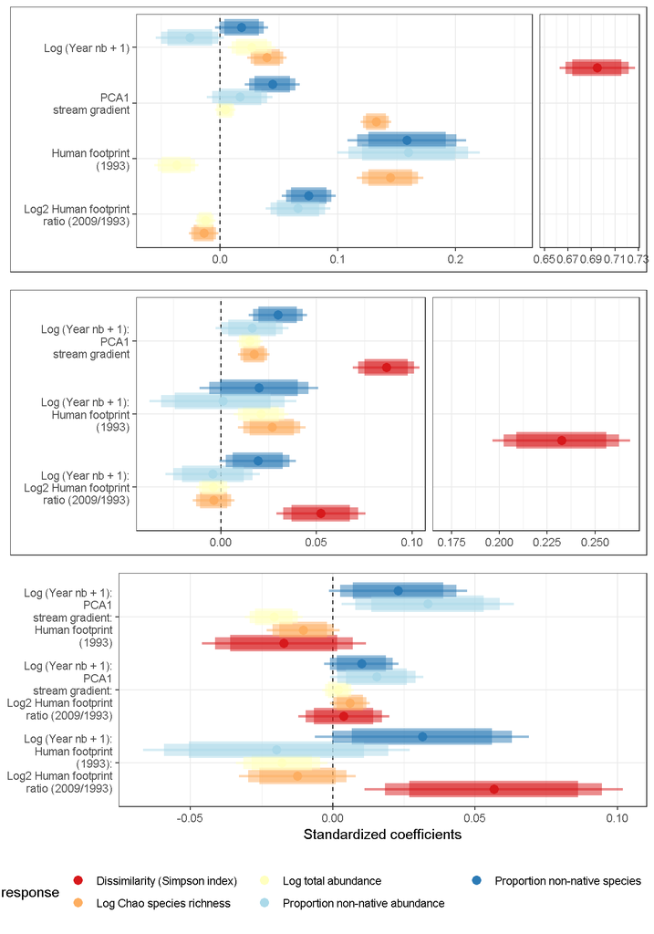

```r
fig1
```

```r
tar_load(site_no_drivers_inla)
cor_site_tps <- cor(site_no_drivers_inla,
  method = "spearman"
)
dimnames(cor_site_tps) <- map(
  dimnames(cor_site_tps),
  ~get_var_replacement()[.x]
)
#corrplot::corrplot(cor_clust, type = "upper", diag = FALSE, tl.srt = 15)
cor_p <- ggcorrplot::ggcorrplot(
  cor_site_tps, hc.order = TRUE, type = "lower",
  lab = TRUE, tl.srt = 15, legend.title = "Spearman Corr") +
theme(legend.position = c(.45, .95), legend.direction = "horizontal") +
guides(colour = guide_legend(title.position = "top"))
```

```r
mod_slp_std_cap <- paste0("(A) Estimated fixed effects of the gaussian models.
  Coefficients were standardized by refiting the models with scaled response and
  explicative variables. Bars represent CI at 95% computed with Wald
  approximation. (B) Interactions effects of pressures on temporal trends
  (Antagonistic or synergetic).")
```

1. Take home results
   1. Temporal dissimilarity within sites increases faster in degraded sites (long & short term)
   2. Evidences of recovery in long-term degraded sites in term of total abundances and species richness, but not in term of exotic species
   3. Even in a dataset containing locations more degraded (hft 1993) than the global freshwater, we found that recent increases in pressure (93-09) increase temporal trends of exotic species percentage (not in abundance, i.e. meaning recent colonisation?), and a decrease of the temporal trends of species richness and of total abundance.
   4. Long & short term pressure interact:
   - Synergistic on dissimilarity and % of exotic species
   - Recent increase in pressure decreases the recovery of total abundance
2. Biodiversity facets:
   1. General:
      1. Positive temporal trends of species richness, total abundance & very weak evidence for exotic species. In accordance with (Klink et al. 2020). We found high species recomposition over time (Dornelas et al. 2014; Blowes et al. 2019)
      2. Jaccard & Simpson based dissimilarity have the same trends everywhere, changes are driven by abundant species
      3. Community temporal changes in composition are mainly driven by turnover (Blowes et al. 2019)
3. Dissimilarity Temporal trends
   - stronger along the stream gradient, long term degraded sites and in sites that have recently increased in degradation
   - Evidences that long term degradation decrease the signature of stream gradient but not for recent degradation
   - Long-term & recent degradation have a synergistic on dissimilarity
4. Richness, abundance & exotic species
   1. More richness downstream, weak evidence for higher abundances
   2. Long-term degradation: strong evidence for higher richness, higher percentage of exotic species and exotic abundance but lower total abundance
   3. Sites that had an recent increase in degradation have overall lower total abundance, weak evidence for lower species richness, strong evidence for higher percentage of exotic species and exotic abundance
   4. Strong evidences that sites that have been degraded (long term)  
      have an higher temporal trends in richness and total abundance (recovery hypothesis Klink et al. (2020)) but no change in exotic species
   5. Sites that recently increase in pressure had higher temporal trends of percentage of exotic species, moderate evidence for temporal decrease of total abundance, very weak evidence for temporal decrease of species richness
   6. Long-term degraded sites had a synergistic effect with stream gradient on exotic species but antagonistic on total abundance
   7. Sites that recently increase in pressure had a synergistic effect with stream gradient on the temporal trends of species richness, total abundance, percentage of exotic species and exotic abundance (can’t find justification for total abundance and species richness)
   8. Long-term degraded sites that had a short term increase in degradation leads to increase of temporal trends of percentage of exotic species and decrease of temporal trends of total abundance (no effect of richness and percentage of exotic abundances)

## 6.2 Typology of biodiversity trends

```r
color_cl_scale <- setNames(pal2, unique(site_cl_rm$cl))
```

```r
pca_clust_cap <- "PCA biplot on site temporal trends (model without
drivers). The sites are colored by their cluster belongings."
```

```r
tar_load(c(pca_clust, site_cl_rm))
pca_clust <- compute_rotated_pca(site_no_drivers_inla_tot, naxis = 5)
p_rotated_pca_clust <- my_pca_plot(
  pca_clust$rotated,
  replace_var = get_var_replacement())
```

```r
tar_load(p_pca_clust)
p_pca_clust <- plot_pca_clust(
     .data = pca_clust$rotated,
     site_cl = site_cl_rm,
     replace_var = get_var_replacement(),
     size_arrows_segment = 1,
     label_size = 2.5,
     alpha_point = .2,
     lim_x_y = c(-3.5, 3.5),
     force_pull = 1,
     force = 80
   )
```

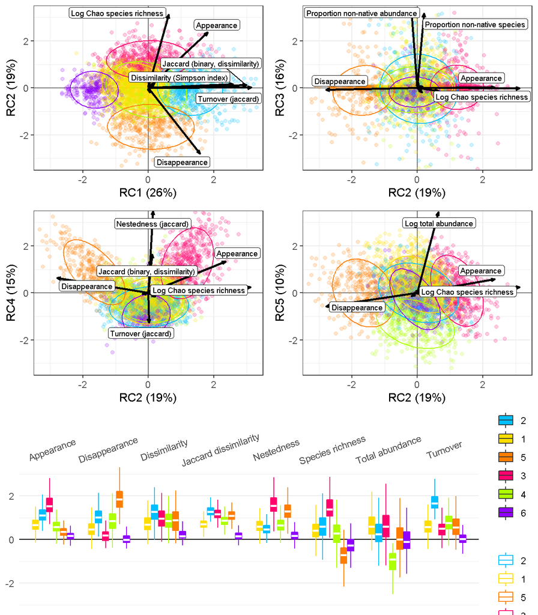

Figure 6.1: PCA biplot on site temporal trends (model without drivers). The sites are colored by their cluster belongings.

```r
axis_l <- list(
  c("RC1", "RC2"),
  c("RC1", "RC3"),
  c("RC1", "RC4"),
  c("RC1", "RC5"),
  c("RC2", "RC3"),
  c("RC2", "RC4"),
  c("RC2", "RC5"),
  c("RC3", "RC4"),
  c("RC3", "RC5"),
  c("RC4", "RC5")
)
p_pca_cl_ell <- map(axis_l,
  ~plot_pca_clust(
     .data = pca_clust$rotated,
     site_cl = site_cl_rm,
     add_point = TRUE,
     add_ellipse = TRUE,
     xaxis = .x[1], yaxis = .x[2],
     ctb_thld = .2,
     replace_var = get_var_replacement(),
     size_arrows_segment = 1,
     label_size = 2.5,
     alpha_point = .2,
     lim_x_y = c(-3.5, 3.5),
     force_pull = 1,
     force = 80,
     var_scaling_factor = 3.5
   ) +
 theme(legend.position = "bottom") +
 scale_color_manual(values = color_cl_scale)
)
leg_cl <- get_legend(p_pca_cl_ell[[1]])
p_pca_cl_ell <- map(p_pca_cl_ell, ~.x + theme(legend.position = "none"))

p_pca_cl_top <- plot_grid(plotlist = p_pca_cl_ell[c(1, 5, 6, 7)], nrow = 2)
p_pca_cl_bt <- target_bp_cl_dist(cl_obj = site_cl_rm) +
  scale_fill_manual(values = color_cl_scale) +
  scale_color_manual(values = color_cl_scale) +
  theme(axis.text.x = element_text(angle = 20, vjust = 0))

plot_grid(
  p_pca_cl_top,
  p_pca_cl_bt,
  nrow = 2,
  rel_heights = c(1, .5)
)
```

```r
site_cl_rm_loc <- site_cl_rm %>%
  select(siteid, cl) %>%
  left_join(loc, by = "siteid") %>%
  filter(ecoregion %in% c("Palearctic", "Nearctic", "Australasia")) %>%
  left_join(
    measurement_exo %>%
      distinct(siteid, basin_name),
    by = "siteid")

n_clust_basin <- site_cl_rm_loc %>%
  group_by(ecoregion, country, basin_name) %>%
  summarise(
    n = n(),
    div = length(unique(cl)),
    evenness = ifelse(div == 1, 1, diversity(table(cl)) / log(div))
  )
basin_name_palearctic <- n_clust_basin %>%
  filter(ecoregion == "Palearctic", div == 6) %>%
  arrange(desc(n), desc(evenness))
#Derwent.UK, Loire, Seine

fq_pal_bas <- site_cl_rm_loc %>%
  filter(basin_name %in% c("Derwent.UK", "Umealven", "Seine")) %>%
  group_by(basin_name, cl) %>%
  summarise(freq = n()) %>%
  mutate(pc = prop.table(freq)) %>%
  ungroup()
fq_pal <- site_cl_rm_loc %>%
  filter(ecoregion == "Palearctic") %>%
  group_by(cl) %>%
  summarise(freq = n()) %>%
  mutate(pc = prop.table(freq), basin_name = toupper("Palearctic")) %>%
  ungroup()

fq_tab <- rbind(
  fq_pal, fq_pal_bas
)

get_fq_tab_from_basin <- function(
  x = site_cl_rm_loc,
  ecoregion = NULL,
  basins = NULL) {

  fq_pal_bas <- x %>%
    filter(basin_name %in% basins) %>%
    group_by(basin_name, cl) %>%
    summarise(freq = n()) %>%
    mutate(pc = prop.table(freq)) %>%
    ungroup()

  ecoregion2 <- ecoregion# to not mess up filter
  fq_pal <- site_cl_rm_loc %>%
    filter(ecoregion == ecoregion2) %>%
    group_by(cl) %>%
    summarise(freq = n()) %>%
    mutate(
      pc = prop.table(freq),
      basin_name = toupper(ecoregion)
      ) %>%
    ungroup()

  fq_tab <- rbind(fq_pal, fq_pal_bas) %>%
    mutate(
      basin_name = factor(
        basin_name, levels = c(toupper(ecoregion), basins)),
      ecoregion = ecoregion
    )
  return(fq_tab)

}

basin_name_palearctic <- n_clust_basin %>%
  filter(ecoregion == "Nearctic", div >= 5) %>%
  arrange(desc(n), desc(evenness))

tab_palearctic <- get_fq_tab_from_basin(
  x = site_cl_rm_loc,
  ecoregion = "Palearctic",
  basins = c("Seine", "Derwent.UK", "Umealven")
)
tab_nearctic <- get_fq_tab_from_basin(
  x = site_cl_rm_loc,
  ecoregion = "Nearctic",
  basins = c("Mississippi", "Saint.Laurent", "Columbia")
)
basin_name_australasia <- n_clust_basin %>%
  filter(ecoregion == "Australasia", div >= 5) %>%
  arrange(desc(n), desc(evenness))

tab_australasia <- get_fq_tab_from_basin(
  x = site_cl_rm_loc,
  ecoregion = "Australasia",
  basins = c("Murray.Darling", "Brisbane", "Logan")
)
tot_tab <- rbind(
  tab_palearctic,
  tab_nearctic,
  tab_australasia) %>%
  group_by(basin_name) %>%
  mutate(
    total_n = sum(freq)) %>%
  ungroup() %>%
  arrange(ecoregion, total_n) %>%
  mutate(
    basin_name_n = paste0(basin_name, " (", total_n, ")"),
    basin_name_f = factor(basin_name_n, levels = unique(basin_name_n))
  )
```